# Used Cars Data Analysis

### Table of Contents:

- Introduction
- Explore Data
- Clean Data
- Exploratory Data Analysis

## Introduction

This is an Exploratory Data Analysis for US used cars, the main goals of the analysis are, familiarize and imporve myself with different data analysis techniques, and to explore the US used cars data set.

### Data

Used Cars Dataset was downloaded from Kaggle website from this [link](https://www.kaggle.com/austinreese/craigslist-carstrucks-data).

## Explore Data

```python
# Import required libraries
import pandas as pd
import numpy as np
import matplotlib.pyplot as plt
import seaborn as sns
```

```python
df_original = pd.read_csv('Used_cars.csv')
```

```python
df = df_original.copy()
```

```python
df.head()
```

|  | Unnamed: 0 | id | url | region | region_url | price | year | manufacturer | model | condition | ... | drive | size | type | paint_color | image_url | description | state | lat | long | posting_date |
| --- | --- | --- | --- | --- | --- | --- | --- | --- | --- | --- | --- | --- | --- | --- | --- | --- | --- | --- | --- | --- | --- |
| 0 | 0 | 7240372487 | https://auburn.craigslist.org/ctd/d/auburn-uni... | auburn | https://auburn.craigslist.org | 35990 | 2010.0 | chevrolet | corvette grand sport | good | ... | rwd | NaN | other | NaN | https://images.craigslist.org/00N0N_ipkbHVZYf4... | Carvana is the safer way to buy a car During t... | al | 32.590000 | -85.480000 | 2020-12-02T08:11:30-0600 |
| 1 | 1 | 7240309422 | https://auburn.craigslist.org/cto/d/auburn-201... | auburn | https://auburn.craigslist.org | 7500 | 2014.0 | hyundai | sonata | excellent | ... | fwd | NaN | sedan | NaN | https://images.craigslist.org/00s0s_gBHYmJ5o7y... | I'll move to another city and try to sell my c... | al | 32.547500 | -85.468200 | 2020-12-02T02:11:50-0600 |
| 2 | 2 | 7240224296 | https://auburn.craigslist.org/cto/d/auburn-200... | auburn | https://auburn.craigslist.org | 4900 | 2006.0 | bmw | x3 3.0i | good | ... | NaN | NaN | SUV | blue | https://images.craigslist.org/00B0B_5zgEGWPOrt... | Clean 2006 BMW X3 3.0I. Beautiful and rare Bl... | al | 32.616807 | -85.464149 | 2020-12-01T19:50:41-0600 |
| 3 | 3 | 7240103965 | https://auburn.craigslist.org/cto/d/lanett-tru... | auburn | https://auburn.craigslist.org | 2000 | 1974.0 | chevrolet | c-10 | good | ... | rwd | full-size | pickup | blue | https://images.craigslist.org/00M0M_6o7KcDpArw... | 1974 chev. truck (LONG BED) NEW starter front ... | al | 32.861600 | -85.216100 | 2020-12-01T15:54:45-0600 |
| 4 | 4 | 7239983776 | https://auburn.craigslist.org/cto/d/auburn-200... | auburn | https://auburn.craigslist.org | 19500 | 2005.0 | ford | f350 lariat | excellent | ... | 4wd | full-size | pickup | blue | https://images.craigslist.org/00p0p_b95l1EgUfl... | 2005 Ford F350 Lariat (Bullet Proofed). This t... | al | 32.547500 | -85.468200 | 2020-12-01T12:53:56-0600 |

5 rows × 26 columns

```python
df.shape
```

```
(458213, 26)
```

```python
df.info()
```

```
<class 'pandas.core.frame.DataFrame'>
RangeIndex: 458213 entries, 0 to 458212
Data columns (total 26 columns):
 #   Column        Non-Null Count   Dtype
---  ------        --------------   -----
 0   Unnamed: 0    458213 non-null  int64
 1   id            458213 non-null  int64
 2   url           458213 non-null  object
 3   region        458213 non-null  object
 4   region_url    458213 non-null  object
 5   price         458213 non-null  int64
 6   year          457163 non-null  float64
 7   manufacturer  439993 non-null  object
 8   model         453367 non-null  object
 9   condition     265273 non-null  object
```

[output cut: 18 more lines]

```python
df.describe()
```

|  | Unnamed: 0 | id | price | year | odometer | lat | long |
| --- | --- | --- | --- | --- | --- | --- | --- |
| count | 458213.000000 | 4.582130e+05 | 4.582130e+05 | 457163.000000 | 4.029100e+05 | 450765.000000 | 450765.000000 |
| mean | 229106.000000 | 7.235233e+09 | 4.042093e+04 | 2010.746067 | 1.016698e+05 | 38.531925 | -94.375824 |
| std | 132274.843786 | 4.594362e+06 | 8.194599e+06 | 8.868136 | 3.228623e+06 | 5.857378 | 18.076225 |
| min | 0.000000 | 7.208550e+09 | 0.000000e+00 | 1900.000000 | 0.000000e+00 | -82.607549 | -164.091797 |
| 25% | 114553.000000 | 7.231953e+09 | 4.900000e+03 | 2008.000000 | 4.087700e+04 | 34.600000 | -110.890427 |
| 50% | 229106.000000 | 7.236409e+09 | 1.099500e+04 | 2013.000000 | 8.764100e+04 | 39.244500 | -88.314889 |
| 75% | 343659.000000 | 7.239321e+09 | 2.149500e+04 | 2016.000000 | 1.340000e+05 | 42.484503 | -81.015022 |
| max | 458212.000000 | 7.241019e+09 | 3.615215e+09 | 2021.000000 | 2.043756e+09 | 82.049255 | 150.898969 |

**There are many irrelevant columns in the next step we will identify and drop them.**

#### Explore some columns

```python
print(list(df['region'].unique()))
```

```
['auburn', 'birmingham', 'dothan', 'florence / muscle shoals', 'gadsden-anniston', 'huntsville / decatur', 'mobile', 'montgomery', 'tuscaloosa', 'anchorage / mat-su', 'fairbanks', 'kenai peninsula', 'southeast alaska', 'flagstaff / sedona', 'mohave county', 'phoenix', 'prescott', 'show low', 'sierra…
```

```python
print(list(df['cylinders'].unique()))
```

```
['8 cylinders', '4 cylinders', '6 cylinders', nan, '10 cylinders', 'other', '5 cylinders', '3 cylinders', '12 cylinders']
```

```python
print(list(df['condition'].unique()))
```

```
['good', 'excellent', nan, 'like new', 'fair', 'salvage', 'new']
```

```python
print(list(df['fuel'].unique()))
```

```
['gas', 'diesel', 'other', 'hybrid', nan, 'electric']
```

```python
print(list(df['title_status'].unique()))
```

```
['clean', 'lien', 'missing', 'salvage', 'rebuilt', nan, 'parts only']
```

```python
print(list(df['transmission'].unique()))
```

```
['other', 'automatic', 'manual', nan]
```

```python
print(list(df['drive'].unique()))
```

```
['rwd', 'fwd', nan, '4wd']
```

```python
print(list(df['paint_color'].unique()))
```

```
[nan, 'blue', 'red', 'silver', 'black', 'white', 'grey', 'orange', 'green', 'yellow', 'custom', 'brown', 'purple']
```

```python
print(list(df['type'].unique()))
```

```
['other', 'sedan', 'SUV', 'pickup', 'coupe', 'van', nan, 'truck', 'mini-van', 'wagon', 'convertible', 'hatchback', 'bus', 'offroad']
```

## Clean Data

### Identify and Remove Duplicates

```python
# count how many duplicated rows we have.
sum(df.duplicated())
```

```
0
```

No duplicatd rows.

### Columns to be deleted (unwanted columns):

- unnamed: 0
- id
- url
- region
- region_url
- VIN
- image_url
- description
- title_status
- size
- condition
- lat
- long
- posting_date

```python
# dropping unwanted columns

col_to_drop=['Unnamed: 0', 'id', 'region', 'url', 'region_url', 'VIN', 'image_url', 'description', 'title_status', 'size',
             'condition','lat', 'long', 'posting_date']
for col in col_to_drop:
    df.drop(col, axis=1, inplace=True)
```

```python
df.shape
```

```
(458213, 12)
```

Before deleting unwanted columns we had **26** columns, now we have **12** columns.

```python
df.info()
```

```
<class 'pandas.core.frame.DataFrame'>
RangeIndex: 458213 entries, 0 to 458212
Data columns (total 12 columns):
 #   Column        Non-Null Count   Dtype
---  ------        --------------   -----
 0   price         458213 non-null  int64
 1   year          457163 non-null  float64
 2   manufacturer  439993 non-null  object
 3   model         453367 non-null  object
 4   cylinders     287073 non-null  object
 5   fuel          454976 non-null  object
 6   odometer      402910 non-null  float64
 7   transmission  455771 non-null  object
 8   drive         324025 non-null  object
 9   type          345475 non-null  object
 10  paint_color   317370 non-null  object
 11  state         458213 non-null  object
dtypes: float64(2), int64(1), object(9)
memory usage: 42.0+ MB
```

### columns with NULLs

**NULLs to be Deleted:**

- year, manufacturer, model, transmission, fuel (These columns have small number of NULLs, deleting NULLs will not affect the results).

**NULLs to be repalced by 'Not Specified':**

- cylinders, drive, type, paint_color.

**NULLs to replaced by the average:**

- odometer

```python
# Delting rows with NULLs
null_col = ['year', 'manufacturer', 'model', 'transmission', 'fuel']
df.dropna(subset=null_col, axis=0, inplace=True)
```

```python
# Replace NULLs by 'Not Specified'
replaced_null_col = ['cylinders', 'drive', 'type', 'paint_color']
for col in replaced_null_col:
    df[col] = df[col].fillna('Not Specified')
```

```python
# Repalce NULLs by column average
null_average_col = ['odometer']
for col in null_average_col:
    df[col] = df[col].fillna(df[col].mean())
```

### Modify Columns Values

**Remove decimal places from year**

```python
# changing year to string
df['year'] = df['year'].astype(str).replace('\.0','', regex=True)
df['year'] = df['year'].astype(int)
```

```python
df.info()
```

```
<class 'pandas.core.frame.DataFrame'>
Int64Index: 430774 entries, 0 to 458211
Data columns (total 12 columns):
 #   Column        Non-Null Count   Dtype
---  ------        --------------   -----
 0   price         430774 non-null  int64
 1   year          430774 non-null  int32
 2   manufacturer  430774 non-null  object
 3   model         430774 non-null  object
 4   cylinders     430774 non-null  object
 5   fuel          430774 non-null  object
 6   odometer      430774 non-null  float64
 7   transmission  430774 non-null  object
 8   drive         430774 non-null  object
 9   type          430774 non-null  object
 10  paint_color   430774 non-null  object
 11  state         430774 non-null  object
dtypes: float64(1), int32(1), int64(1), object(9)
memory usage: 41.1+ MB
```

```python
df.head()
```

|  | price | year | manufacturer | model | cylinders | fuel | odometer | transmission | drive | type | paint_color | state |
| --- | --- | --- | --- | --- | --- | --- | --- | --- | --- | --- | --- | --- |
| 0 | 35990 | 2010 | chevrolet | corvette grand sport | 8 cylinders | gas | 32742.0 | other | rwd | other | Not Specified | al |
| 1 | 7500 | 2014 | hyundai | sonata | 4 cylinders | gas | 93600.0 | automatic | fwd | sedan | Not Specified | al |
| 2 | 4900 | 2006 | bmw | x3 3.0i | 6 cylinders | gas | 87046.0 | automatic | Not Specified | SUV | blue | al |
| 3 | 2000 | 1974 | chevrolet | c-10 | 4 cylinders | gas | 190000.0 | automatic | rwd | pickup | blue | al |
| 4 | 19500 | 2005 | ford | f350 lariat | 8 cylinders | diesel | 116000.0 | automatic | 4wd | pickup | blue | al |

```python
df.describe()
```

|  | price | year | odometer |
| --- | --- | --- | --- |
| count | 4.307740e+05 | 430774.000000 | 4.307740e+05 |
| mean | 2.527227e+04 | 2011.079768 | 1.011342e+05 |
| std | 5.527825e+06 | 8.140668 | 3.122011e+06 |
| min | 0.000000e+00 | 1900.000000 | 0.000000e+00 |
| 25% | 4.990000e+03 | 2008.000000 | 4.634300e+04 |
| 50% | 1.099500e+04 | 2013.000000 | 9.821200e+04 |
| 75% | 2.120000e+04 | 2016.000000 | 1.271018e+05 |
| max | 3.615215e+09 | 2021.000000 | 2.043756e+09 |

### Detecting Outliers

```python
Q1 = df.quantile(0.25)
Q3 = df.quantile(0.75)
IQR = Q3 - Q1
IQR
```

```
price       16210.00
year            8.00
odometer    80758.75
dtype: float64
```

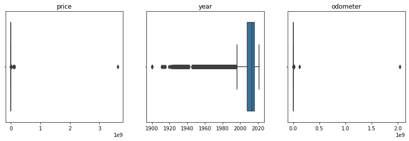

```python
fig, axes = plt.subplots(1, 3, figsize=(14, 4), sharey=True)
plt.subplots_adjust(hspace = 0.4)
x_pos = 0
y_pos = 0
for col in range(len(IQR)):
    g = sns.boxplot(ax=axes[col],x=df[IQR.keys()[col]]);
    g = g.set(xlabel=None)
    g = axes[col].set_title(IQR.keys()[col])
```

Let's count the number of outliers

```python
l_outlier = Q1 - 1.5 * IQR
u_outlier = Q3 + 1.5 * IQR
list1 = list(IQR.keys())
for col in range(len(IQR)):
    col_name = IQR.keys()[col]
    print('Number of outliers in', col_name,':', len(df.query(f'{col_name} < {l_outlier[col]}')) + len(df.query(f'{col_name} > {u_outlier[col]}')))
```

```
Number of outliers in price : 11837
Number of outliers in year : 13027
Number of outliers in odometer : 5523
```

**Since the number of ouiers is not small we will just leave them.**

### Capitalize State Column

```python
df['state'] = df['state'].str.upper()
```

```python
df['state'].unique()
```

```
array(['AL', 'AK', 'AZ', 'AR', 'CA', 'CO', 'CT', 'DC', 'DE', 'FL', 'GA',
       'HI', 'ID', 'IL', 'IN', 'IA', 'KS', 'KY', 'LA', 'ME', 'MD', 'MA',
       'MI', 'MN', 'MS', 'MO', 'MT', 'NC', 'NE', 'NV', 'NJ', 'NM', 'NY',
       'NH', 'ND', 'OH', 'OK', 'OR', 'PA', 'RI', 'SC', 'SD', 'TN', 'TX',
       'UT', 'VT', 'VA', 'WA', 'WV', 'WI', 'WY'], dtype=object)
```

## Exploratory Data Analysis

#### Top 20 Manufacturer

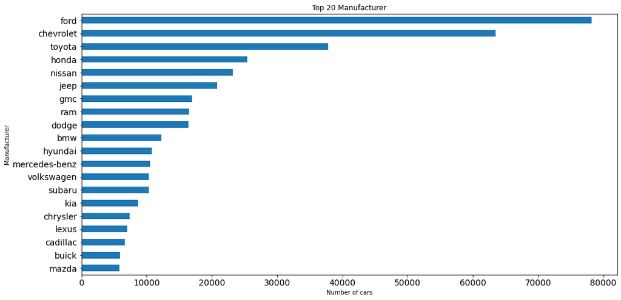

```python
top_manu = df.manufacturer.value_counts().nlargest(20)
top_manu.plot(kind='barh', figsize=(16,8), fontsize=14).invert_yaxis()

plt.title("Top 20 Manufacturer")
plt.ylabel('Manufacturer')
plt.xlabel('Number of cars');
```

#### Fuel Types Percentage

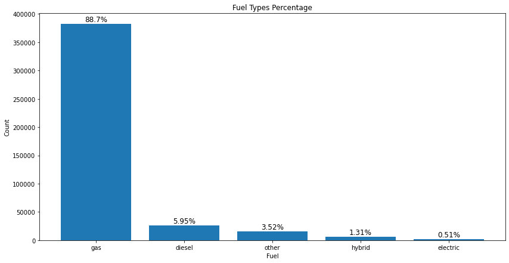

```python
fuel_types = df['fuel'].value_counts()
plt.figure(figsize=[14, 7])
x = fuel_types.index
y = fuel_types
plt.title("Fuel Types Percentage")
plt.xlabel("Fuel")
plt.ylabel("Count")
plt.bar(x, y );

for index, value in enumerate(y):
    plt.text(index, value, str(round(value / df.shape[0] * 100,2)) +'%\n', fontsize=12,
                           horizontalalignment='center', verticalalignment='center');
```

It is obvious that most of the cars in our dataset are running by gas with almost 90% of the cars.

Interestingly, around 0.5% of the cars are electric.

#### Drive Distribution

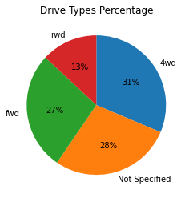

```python
drive_types = df['drive'].value_counts()
plt.title("Drive Types Percentage")
plt.pie(drive_types, labels = drive_types.index, autopct='%1.0f%%',startangle = 90,
        counterclock = False);
```

#### Transmission Distribution

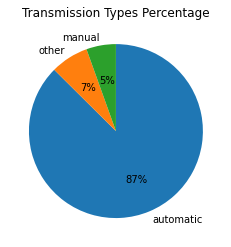

```python
transmission_types = df['transmission'].value_counts()
plt.title("Transmission Types Percentage")
plt.pie(transmission_types, labels = transmission_types.index, autopct='%1.0f%%',startangle = 90,
        counterclock = False);
```

As expected, most of the cars have automatic transmission type.

#### Drive Types

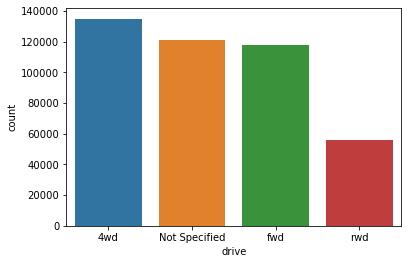

```python
sns.countplot(data = df, x = 'drive', order=df['drive'].value_counts().index);
```

Most of the cars are 4wd, also we have a huge number of Not Specified drive type.

#### Cars Types

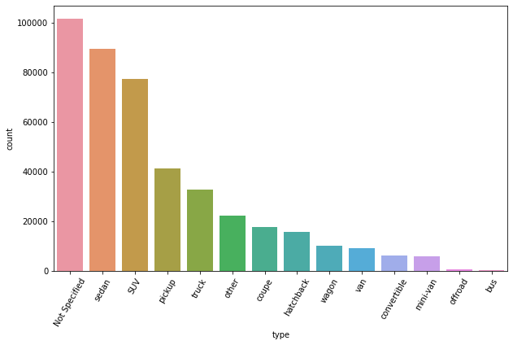

```python
fig_dims = (10,6)
fig, ax = plt.subplots(figsize=fig_dims)
plt.xticks(rotation=60)
sns.countplot(data = df, x = 'type', order=df['type'].value_counts().index);
```

#### Cylinders

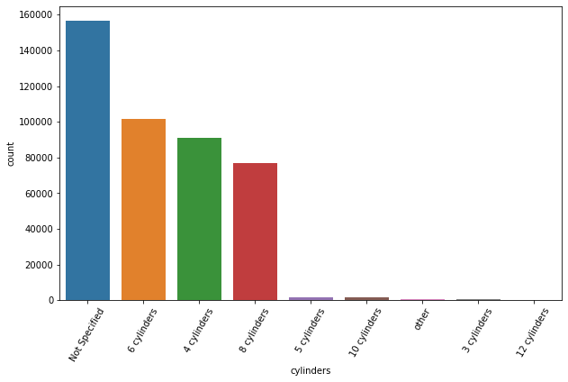

```python
fig_dims = (10,6)
fig, ax = plt.subplots(figsize=fig_dims)
plt.xticks(rotation=60)
sns.countplot(data = df, x = 'cylinders', order=df['cylinders'].value_counts().index);
```

#### Cars Colors

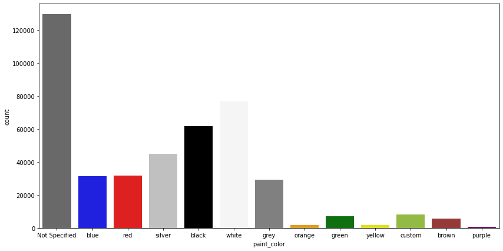

```python
plt.figure(figsize=[14, 7])
palette = sns.color_palette(['dimgrey', 'blue', 'red', 'silver', 'black', 'whitesmoke', 'grey', 'orange', 'green',
                             'yellow', 'yellowgreen','brown', 'purple'])

sns.countplot(data = df, x = 'paint_color', palette=palette);
```

#### Number of Cars in Last 20 years

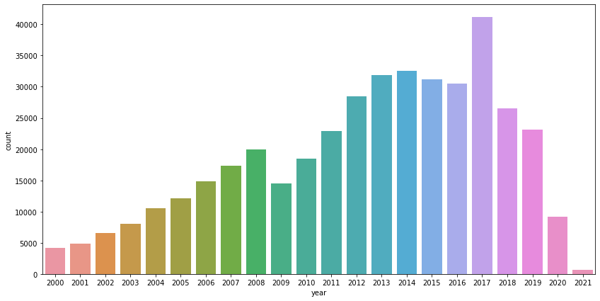

```python
plt.figure(figsize=[14, 7])
years = df.query('year >= 2000')
sns.countplot(data = years, x= years.year);
```

We can see that the number of cars has been increasing dramatically from 2000 till 2017, after 2017 the number is starting to decrease

#### Manufacturer with Highest Total an Highest Average Odometer

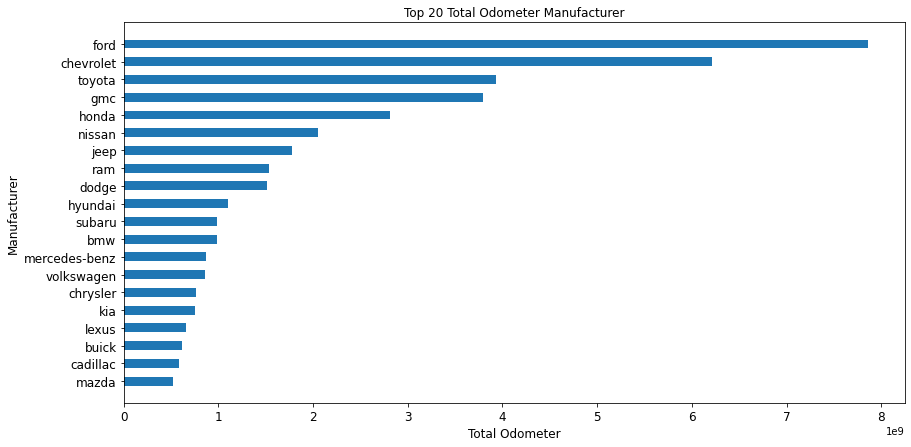

```python
top_odo = df.groupby(["manufacturer"]).sum()['odometer'].nlargest(20)

plt.figure(figsize=[14, 7])
plt.title('Top 20 Total Odometer Manufacturer')
plt.xlabel('Total Odometer', fontsize=12)
plt.ylabel('Manufacturer', fontsize=12)
plt.xticks(fontsize=12)
plt.yticks(fontsize=12)
plt.barh(y=top_odo.index, width=top_odo, height=0.5)
plt.gca().invert_yaxis()
```

It seems that manufacturers with hightest occurance have the highest total odometer. Let's check the average...

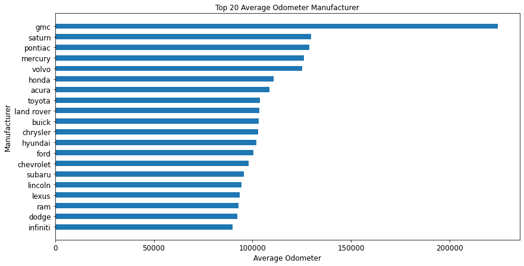

```python
top_odo_avg = df.groupby(["manufacturer"]).mean()['odometer'].nlargest(20)

plt.figure(figsize=[14, 7])
plt.title('Top 20 Average Odometer Manufacturer')
plt.xlabel('Average Odometer', fontsize=12)
plt.ylabel('Manufacturer', fontsize=12)
plt.xticks(fontsize=12)
plt.yticks(fontsize=12)
plt.barh(y=top_odo_avg.index, width=top_odo_avg, height=0.5)
plt.gca().invert_yaxis()
```

#### How Many Manufacturer are in Both Top 20 Occurrence and Average Odometer

```python
manu_top_and_avg = set(top_manu.index).intersection(top_odo_avg.index)
print(list(manu_top_and_avg), '\n with total number of:', len(manu_top_and_avg), 'manufacturer')
```

```
['hyundai', 'buick', 'gmc', 'ford', 'chevrolet', 'ram', 'subaru', 'lexus', 'dodge', 'chrysler', 'honda', 'toyota']
 with total number of: 12 manufacturer
```

The following manufacturer are in both Top 20 Occurrence and Average Odometer: **'buick', 'honda', 'subaru', 'dodge', 'lexus', 'toyota', 'chevrolet', 'chrysler', 'ford', 'ram', 'hyundai', 'gmc'**, with total count of **12 manufacturer**.

#### Manufacturer with Highest Total and Highest Average Price

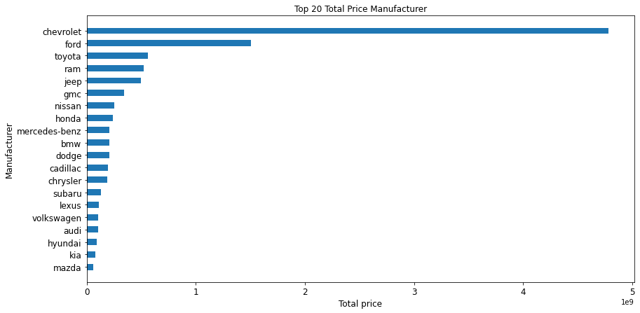

```python
top_price = df.groupby(["manufacturer"]).sum()['price'].nlargest(20)

plt.figure(figsize=[14, 7])
plt.title('Top 20 Total Price Manufacturer')
plt.xlabel('Total price', fontsize=12)
plt.ylabel('Manufacturer', fontsize=12)
plt.xticks(fontsize=12)
plt.yticks(fontsize=12)
plt.barh(y=top_price.index, width=top_price, height=0.5)
plt.gca().invert_yaxis()
```

even though ford has much more cars, but it comes in the second place after chevrolet in the total price.

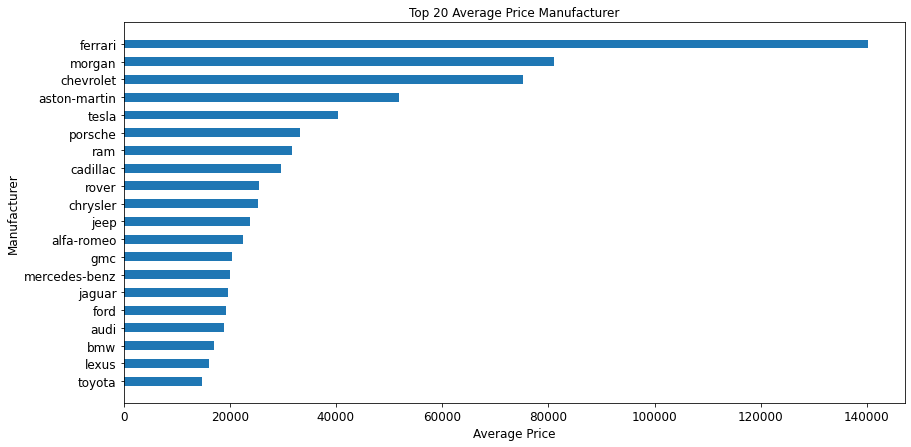

```python
top_price_avg = df.groupby(["manufacturer"]).mean()['price'].nlargest(20)

plt.figure(figsize=[14, 7])
plt.title('Top 20 Average Price Manufacturer')
plt.xlabel('Average Price', fontsize=12)
plt.ylabel('Manufacturer', fontsize=12)
plt.xticks(fontsize=12)
plt.yticks(fontsize=12)
plt.barh(y=top_price_avg.index, width=top_price_avg, height=0.5)
plt.gca().invert_yaxis()
```

In the average price we can see many new manufacturers and the order is totally different than the total price

#### Top 20 States With Total Number of Cars

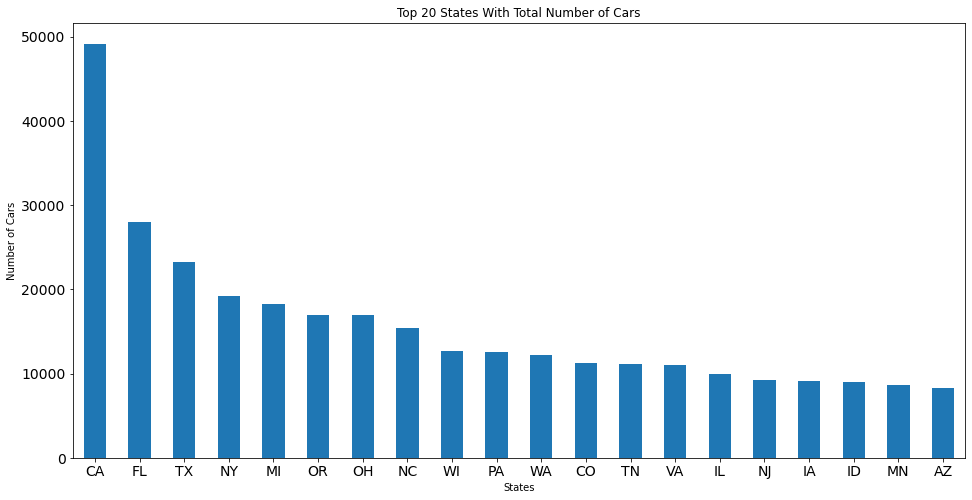

```python
top_state = df.state.value_counts().nlargest(20)
top_state.plot(kind='bar', figsize=(16,8), fontsize=14)

plt.title("Top 20 States With Total Number of Cars")
plt.ylabel('Number of Cars')
plt.xticks(rotation=0)
plt.xlabel('States');
```

CA has the greatest percentage of cars with more than 40,000 cars, and with around 20,000 cars diffrence from the next state, which is FL.

#### Top 20 States With Total Price

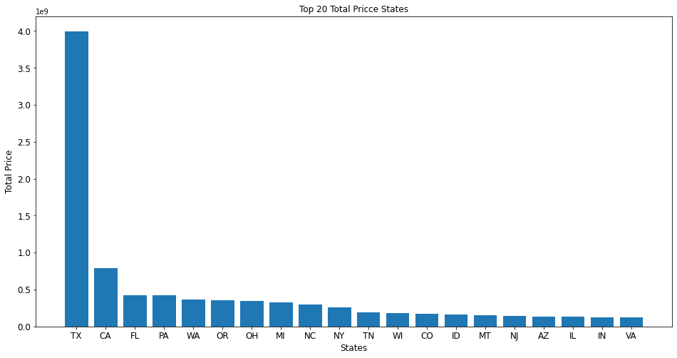

```python
top_state_price = df.groupby(["state"]).sum()['price'].nlargest(20)

plt.figure(figsize=[16, 8])
plt.title('Top 20 Total Pricce States')
plt.xlabel('States', fontsize=12)
plt.ylabel('Total Price', fontsize=12)
plt.xticks(fontsize=12)
plt.yticks(fontsize=12)

plt.bar(x=top_state_price.index, height=top_state_price);
```

TX has the biggest total price, even though, it was third on total count. As for CA it comes second.

#### Top 20 States With Average Price

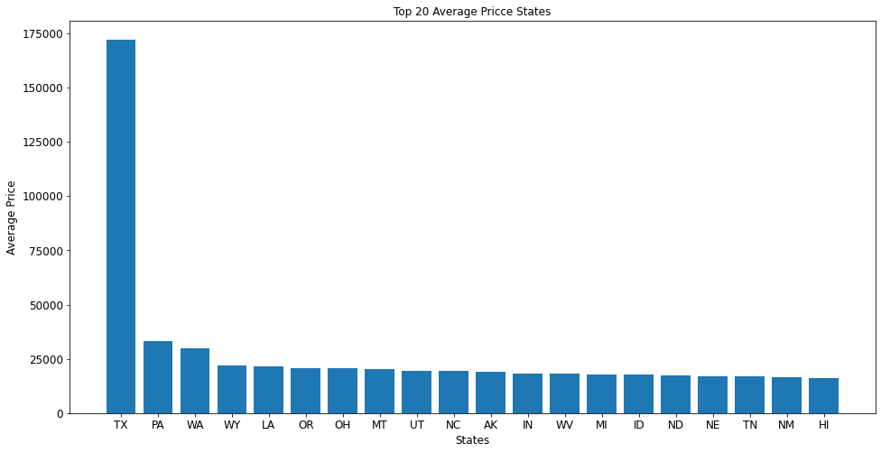

```python
top_state_price_avg = df.groupby(["state"]).mean()['price'].nlargest(20)

plt.figure(figsize=[16, 8])
plt.title('Top 20 Average Pricce States')
plt.xlabel('States', fontsize=12)
plt.ylabel('Average Price', fontsize=12)
plt.xticks(fontsize=12)
plt.yticks(fontsize=12)

plt.bar(x=top_state_price_avg.index, height=top_state_price_avg);
```

#### Mean Price Per Year

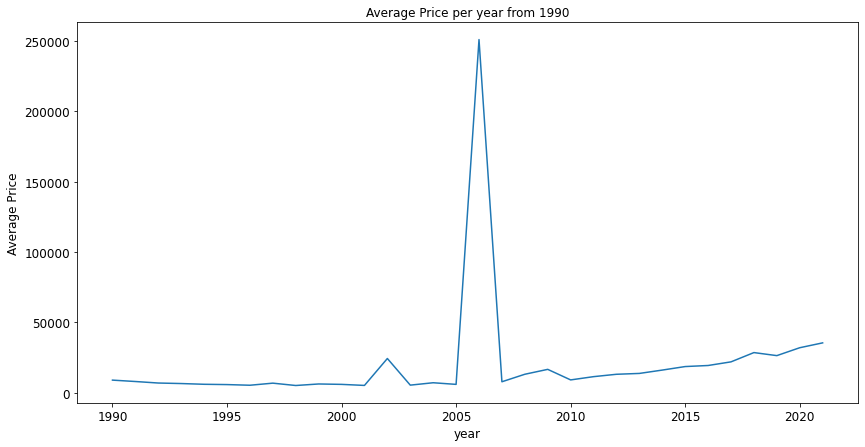

```python
year_price_avg = df.groupby(df.query('year >= 1990')['year']).mean()['price']
plt.figure(figsize=[14, 7])
plt.title('Average Price per year from 1990')
plt.xlabel('year', fontsize=12)
plt.ylabel('Average Price', fontsize=12)
plt.xticks(fontsize=12)
plt.yticks(fontsize=12)
plt.plot(year_price_avg.index,year_price_avg)
plt.gca();
```

The average price per is increasing as we move on years, but in year 2006 there is dramatic increase with average of $250,000, while other years are ranging from [5,000 - 50,000].

#### Colors Average Price

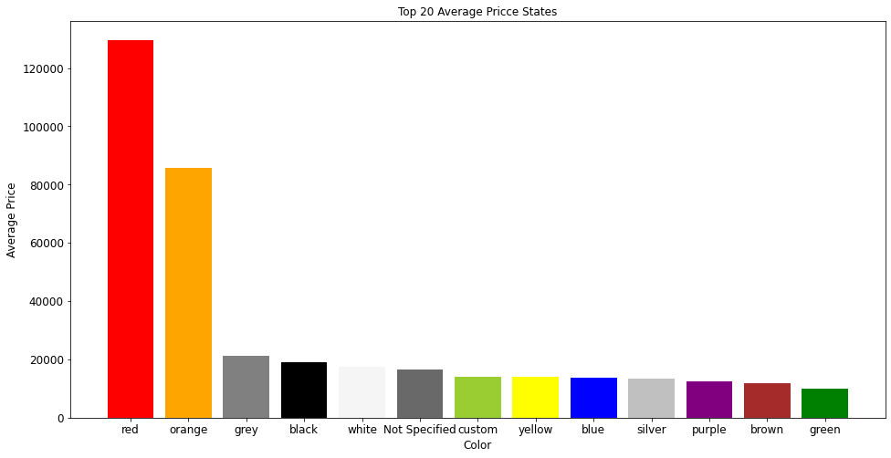

```python
top_color_price_avg = df.groupby(["paint_color"]).mean()['price'].nlargest(13)

plt.figure(figsize=[16, 8])
plt.title('Top 20 Average Pricce States')
plt.xlabel('Color', fontsize=12)
plt.ylabel('Average Price', fontsize=12)
plt.xticks(fontsize=12)
plt.yticks(fontsize=12)


colors = ['red', 'orange', 'grey', 'black', 'whitesmoke', 'dimgrey', 'yellowgreen', 'yellow', 'blue',
                             'silver', 'purple','brown', 'green']

plt.bar(x=top_color_price_avg.index, height=top_color_price_avg, color=colors);
```

Although, Red cars were the fifth in total count, here they have the highest average price with big difference from the others.

#### Fuel Type Average Price

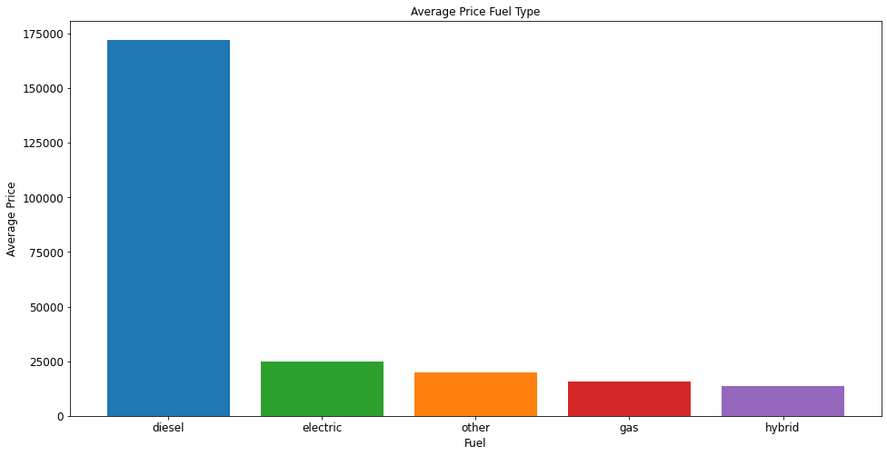

```python
top_fuel_price_avg = df.groupby(["fuel"]).mean()['price'].nlargest(20)

plt.figure(figsize=[16, 8])
plt.title('Average Price Fuel Type')
plt.xlabel('Fuel', fontsize=12)
plt.ylabel('Average Price', fontsize=12)
plt.xticks(fontsize=12)
plt.yticks(fontsize=12)

plt.bar(x=top_fuel_price_avg.index, height=top_fuel_price_avg, color=['tab:blue', 'tab:green', 'tab:orange', 'tab:red', 'tab:purple' ]);
```

Surprisingly, diesel cars have the highest averge price, followed by electric cars, other, and the gas cars, finally, hybrid cars.

#### Drive Types average Price

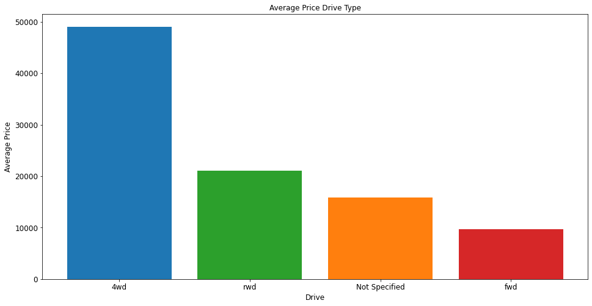

```python
top_drive_price_avg = df.groupby(["drive"]).mean()['price'].nlargest(20)

plt.figure(figsize=[16, 8])
plt.title('Average Price Drive Type')
plt.xlabel('Drive', fontsize=12)
plt.ylabel('Average Price', fontsize=12)
plt.xticks(fontsize=12)
plt.yticks(fontsize=12)

plt.bar(x=top_drive_price_avg.index, height=top_drive_price_avg, color=['tab:blue', 'tab:green',
                                                                      'tab:orange', 'tab:red']);
```

4wd cars have highest average price, then rwd, Not Specified, fwd.

#### Cylinders Average Price

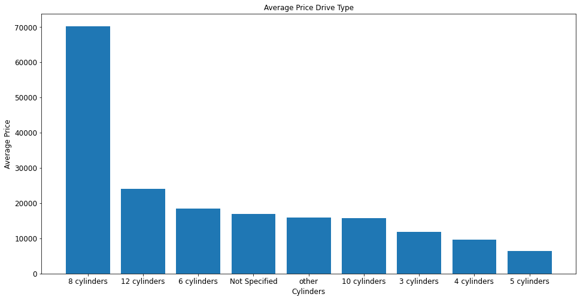

```python
top_drive_price_avg = df.groupby(["cylinders"]).mean()['price'].nlargest(20)

plt.figure(figsize=[16, 8])
plt.title('Average Price Drive Type')
plt.xlabel('Cylinders', fontsize=12)
plt.ylabel('Average Price', fontsize=12)
plt.xticks(fontsize=12)
plt.yticks(fontsize=12)

plt.bar(x=top_drive_price_avg.index, height=top_drive_price_avg);
```

#### Types Average Price

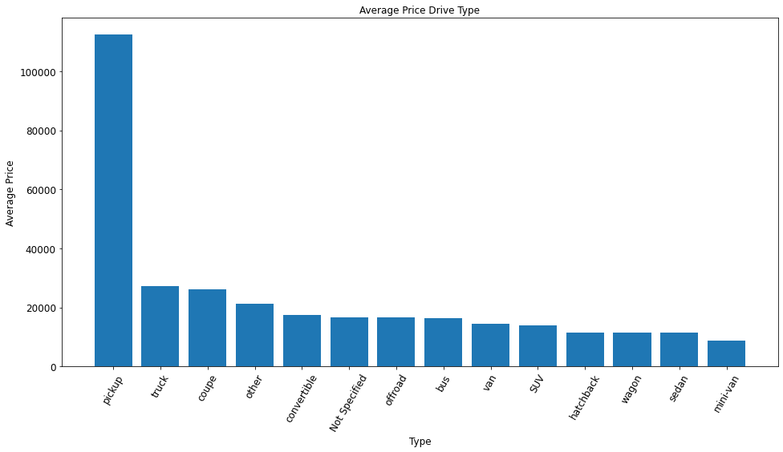

```python
top_type_price_avg = df.groupby(["type"]).mean()['price'].nlargest(20)

plt.figure(figsize=[16, 8])
plt.title('Average Price Drive Type')
plt.xlabel('Type', fontsize=12)
plt.ylabel('Average Price', fontsize=12)
plt.xticks(fontsize=12, rotation=60)
plt.yticks(fontsize=12)

plt.bar(x=top_type_price_avg.index, height=top_type_price_avg);
```

#### Transmission Types Average Price

[figure not shown]

```python
top_trans_price_avg = df.groupby(["transmission"]).mean()['price'].nlargest(20)

plt.figure(figsize=[16, 8])
plt.title('Average Price Transmission Type')
plt.xlabel('Transmission', fontsize=12)
plt.ylabel('Average Price', fontsize=12)
plt.xticks(fontsize=12, rotation=60)
plt.yticks(fontsize=12)

plt.bar(x=top_type_price_avg.index, height=top_type_price_avg);
```